# MTH6139 Time Series

Coursework 1

School of Mathematical Sciences ID:210202621

March 2024

## Section 1

### This project uses Meta’s Prophet forecasting system to predict the future of CO2 emission

Using install.packages(“prophet”) I installed the prophet library to R.

```r
library(prophet)
```

This loads the library Meta prophet.

## Data information

```r
co2.df = data.frame(
  ds=zoo::as.yearmon(time(co2)),
  y=co2)
```

co2 is a time series spanning from 1959 to 1997 with a monthly period. The data frame collates the data into a table to make it more readable, the time function allows us to access the time series objects.

```r
co2model = prophet::prophet(co2.df,weekly.seasonality = TRUE)
```

calling prophet,we fit co2.df.

```r
futuredata = prophet::make_future_dataframe(co2model, periods=24,freq = "month")
```

The make_future_dataframe function uses co2model and the number of periods to create a new data frame so we can predict the future data.

```r
futureprediction = predict(co2model,futuredata)
```

Using the co2model and the given parameter from the futuredata dataframe we predict/forecast the future data and store it.

## Future Prediction

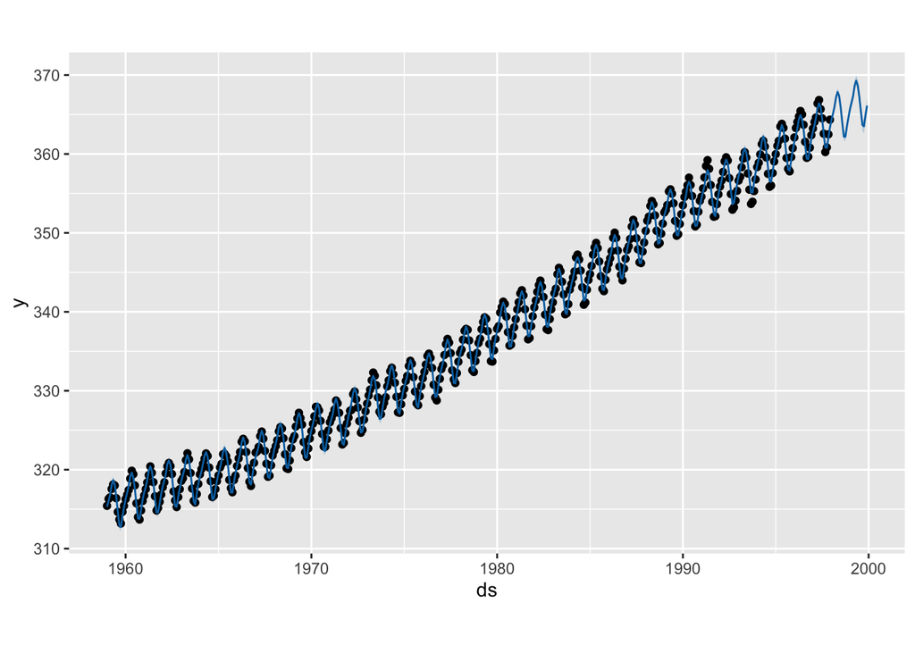

```r
plot(co2model,futureprediction)
```

This plots the original co2 data and also plots the prediction of the future co2 emissions extrapolated from past data, as you can see in the plot it shows the future data to date December 1999 for future co2 emission which is 24 months from where the data ends.

## Dynamic Plot

```r
dyplot.prophet(co2model,futureprediction)
```

[interactive chart not shown]

This is an interactive version of the plot above so you can also analyse it in more detail

## Trend,Yearly seasonality and Weekly seasonality

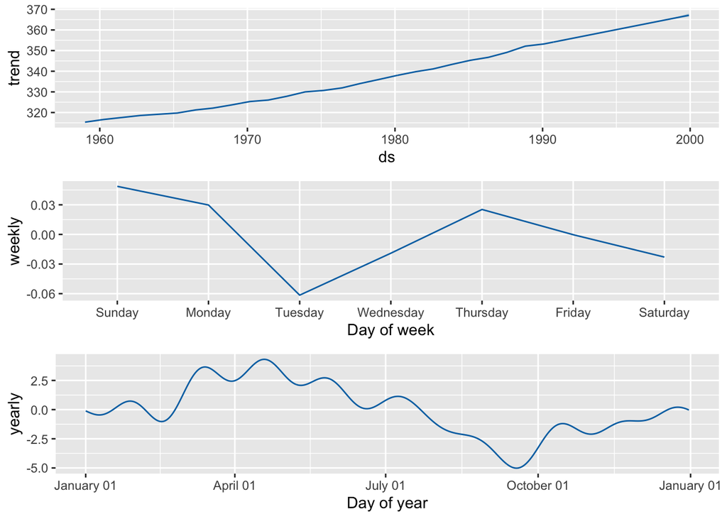

```r
prophet_plot_components(co2model,futureprediction)
```

ppm unit-Parts per Million

The trend suggests a positive correlation, this means the concentration of co2 has increased significantly up until 1999.This trend as well as the prediction shows that the concentration of co2 in the atmosphere will increase further.

The weekly seasonality suggests that on Sunday, Monday and Thursdays, the atmosphere co2 concentration is the highest ,at approximately 0.045ppm,0.03ppm and 0.03ppm respectively, on those days throughout the week. On Tuesday it is at its lowest at -0.06ppm.